# Problem Set 4

Juan Fernando Contreras - Mariana Baquero Jara

2024-06-05

Inicialmente voy a llamar los paquetes que quiero usar para este taller

```r
#instalar/llamar pacman
require(pacman)

#uso la funcion p_load de pacman para instalar/llamar las librerias que se usaran en el problem set
p_load(rio, # funcion import/export: permite leer/escribir archivos desde diferentes formatos
       skimr, # funcion skim: describe un conjunto de datos
       janitor, # contiene conjuntos de datos
       tidyverse, # manipular/limpiar conjuntos de datos
       dplyr, #manipular dataframes
       data.table, # renombar variables
       sf, #Manipular datos espaciales
       rvest, #Manipular HTML
       mapview, #Visualizar datos espaciales interactivamente
       tmaptools, #Para mapas y manipulacion de datos espaciales
       osmdata, #Manipular y descargar datos
       ggplot2, #Creacion de graficos
       viridis) #para la paleta de colores
```

## Primer Punto.

Aquí vamos a extraer la información de internet. Nos dirimos a la página ahttps://eduard-martinez.github.io/pset-4.html y examinamos su contenido. A continuación, se describe el proceso desde la obtención de la información hasta la preparación:

```r
#1.1 Obtener las URL

#Se crea una variable a la que se le asigna la URL de la pagina
htmlprofe="https://eduard-martinez.github.io/pset-4.html"
#Leer el contenido de la pagina y asignarlo en una variable
pagina=read_html(htmlprofe)
#Almacenar el vector de URLs contenidos en la pagina
url_full= pagina %>% html_nodes("a") %>% html_attr("href")

#1.2 Filtrar URL
url_subset=url_full[str_detect(url_full, pattern = "propiedad")]

#1.3 Extraer las tablas de los HTML
lista_tablas=list()

#Se crea un bucle que itera cada i (elemento) en url_subset
for (i in url_subset) {
  #Se crea la variable pagina para almacenar el contenido de la pagina web de cada iteracion
  pagina = read_html(i)
  #Se crea una variable "tabla" que almacena las tablar de la pagina y se utiliza "fill=TRUE" para las celdas faltantes
  tabla = pagina %>% html_table(fill = TRUE)
  #Se crea una lista que se le asigna la primera tabla (1) segun cada iteracion
  lista_tablas[[i]] = tabla[[1]]
}

#Se unen todas las tablas en el dataframe "db_house"
db_house=rbindlist(lista_tablas)
```

## Segundo Punto.

Aquí vamos a realizar un análisis con la información que tenemos. A continuación, se describe el de la creación del mapa solicitado en el problem set 4:

```r
#Se convierte una columna de "db_house" en un SimpleFeature
db_house$geometry <- st_as_sfc(db_house$geometry, crs = 4326)

#Se convierte el dataframe a un SimpleFeature
sf_house=st_as_sf(db_house, sf_column_name = "geometry")
#Comprobar que sea SimpleFeature
class(sf_house)
```

```
## [1] "sf"         "data.table" "data.frame"
```

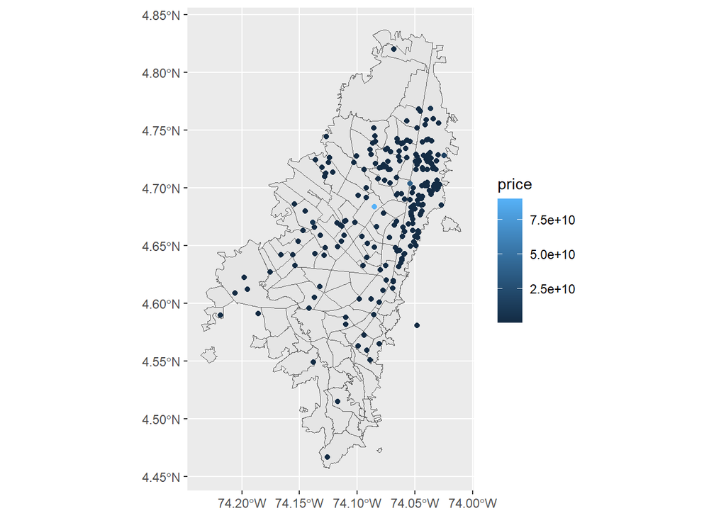

```r
#Se halla los datos de Bogota Colombia
bog <- opq(bbox = getbb("Bogota Colombia")) %>%
  #Segun administrativo
  add_osm_feature(key="boundary", value="administrative") %>%
  #Ejecuto en SimpleFeature
  osmdata_sf()

#Solo administrativos del nivel 9 y excluyendo ciertos IDs
bog <- bog$osm_multipolygons %>% subset(admin_level==9 & !osm_id %in% 16011743:16011744)

#Se crea el mapa al usar ggplot
mapa=ggplot() + geom_sf(data=bog) + geom_sf(data=sf_house, aes(color=price))+
  scale_fill_viridis(option = "A" , name = "Price")
mapa
```

## Bono.

En primer lugar, realizamos estadísticas descriptivas:

```
##        V1               V1             rooms           bedrooms
##  Min.   :   679   Min.   :   679   Min.   : 1.000   Min.   : 0.000
##  1st Qu.: 54061   1st Qu.: 54061   1st Qu.: 2.000   1st Qu.: 2.000
##  Median :111370   Median :111370   Median : 3.000   Median : 3.000
##  Mean   :114243   Mean   :114243   Mean   : 2.975   Mean   : 3.127
##  3rd Qu.:171246   3rd Qu.:171246   3rd Qu.: 3.000   3rd Qu.: 3.000
##  Max.   :238654   Max.   :238654   Max.   :12.000   Max.   :12.000
##                                    NA's   :139      NA's   :149
##    bathrooms      surface_total    surface_covered        price
##  Min.   : 1.000   Min.   :  35.0   Min.   :   35.00   Min.   :1.900e+07
##  1st Qu.: 2.000   1st Qu.:  70.0   1st Qu.:   70.75   1st Qu.:3.000e+08
##  Median : 2.000   Median : 109.0   Median :  108.00   Median :4.775e+08
##  Mean   : 2.593   Mean   : 248.1   Mean   :  401.01   Mean   :1.400e+09
##  3rd Qu.: 3.000   3rd Qu.: 218.0   3rd Qu.:  188.25   3rd Qu.:8.885e+08
##  Max.   :10.000   Max.   :3340.0   Max.   :21424.00   Max.   :9.000e+10
##  NA's   :43       NA's   :155      NA's   :136
##  property_type           lat             lon                  geometry
##  Length:220         Min.   :4.467   Min.   :-74.22   POINT        :220
##  Class :character   1st Qu.:4.653   1st Qu.:-74.09   epsg:4326    :  0
##  Mode  :character   Median :4.693   Median :-74.06   +proj=long...:  0
##                     Mean   :4.683   Mean   :-74.07
##                     3rd Qu.:4.723   3rd Qu.:-74.05
##                     Max.   :4.820   Max.   :-74.02
##
```

El conjunto de datos analizado refleja varias características de propiedades inmobiliarias, incluyendo el número de habitaciones, dormitorios, baños, así como detalles sobre las superficies y los precios. La mayoría de las propiedades tienen 3 habitaciones y 3 dormitorios, indicado por las medianas y los terceros cuartiles. Sin embargo, el máximo de 12 en ambas categorías sugiere la presencia de propiedades de gran tamaño o posibles anomalías en los datos.

La distribución de los baños muestra que la mayoría de las propiedades tienen entre 2 y 3, con un promedio ligeramente superior a 2.5. Esto sugiere que es común que las propiedades incluyan múltiples baños. Las variables de superficie, tanto total como cubierta, exhiben una gran variabilidad y valores extremadamente altos, lo que indica un sesgo hacia propiedades más grandes o atípicas. Este sesgo también se observa en los precios, que varían desde 19 millones hasta 90 mil millones, con una media mucho mayor que la mediana, reflejando la influencia de propiedades de alto valor en el conjunto.

Ahora, revisamos algunas gráficos de distribución de las variables de interés:

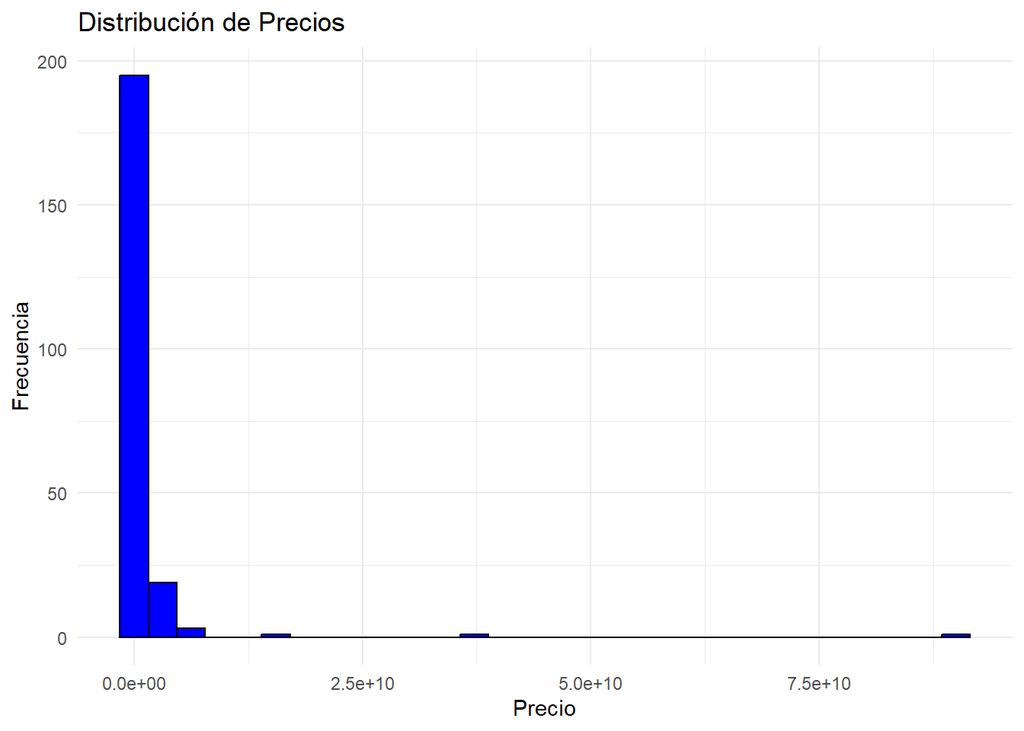

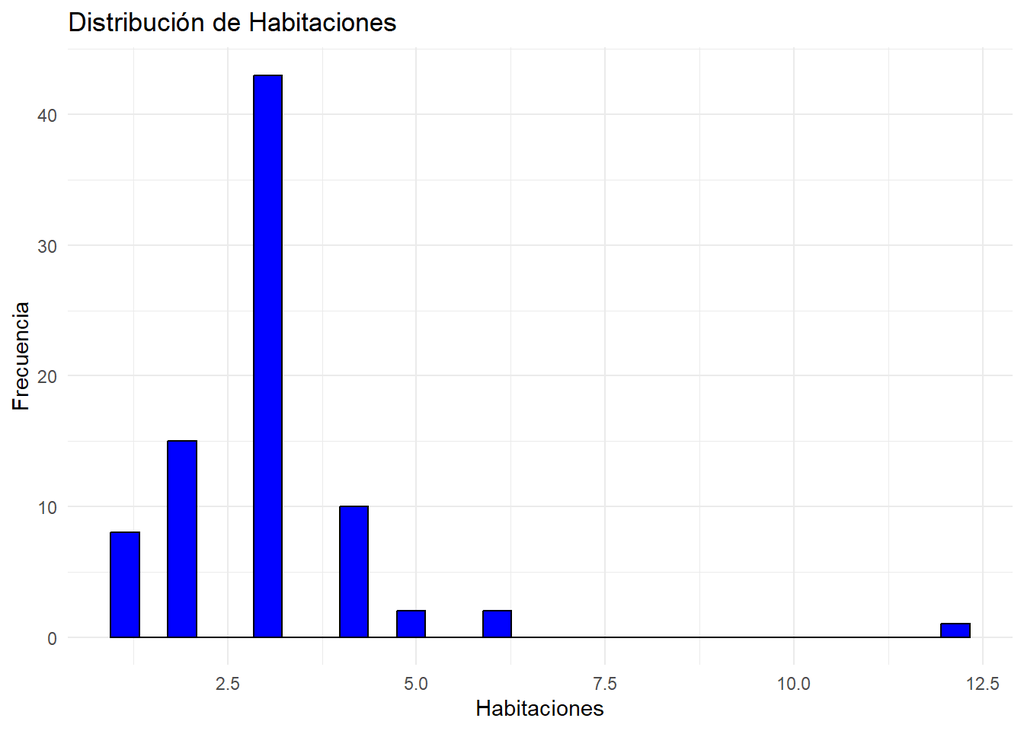

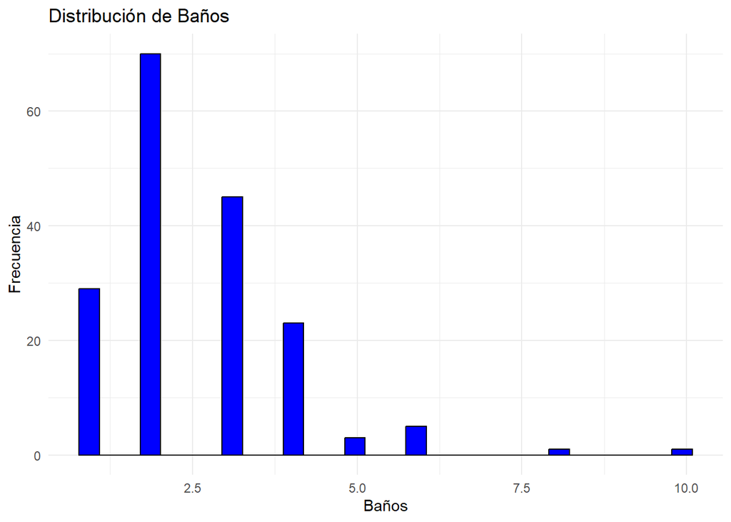

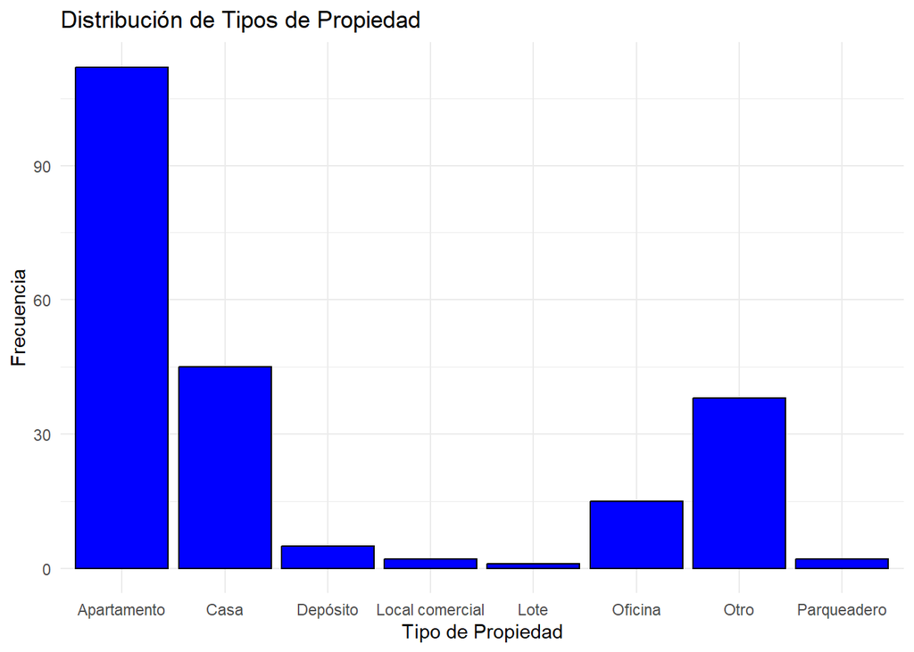

Los gráficos destacan una notable disparidad en el mercado inmobiliario. Mientras la mayoría de las propiedades se agrupan en un rango de precio accesible, un pequeño segmento alcanza valores extremadamente altos, lo que podría indicar una presencia significativa de propiedades de lujo o altamente especializadas. A nivel de tipo de propiedad, los apartamentos dominan claramente el mercado, reflejando una tendencia urbana hacia la vivienda compacta y eficiente. Este análisis sugiere un mercado dividido, con una amplia oferta de propiedades estándar complementada por una exclusiva selección de unidades de alto valor, lo cual plantea consideraciones importantes para estrategias de inversión y desarrollo urbano.